# IODS course project

Pekka Päärni

# About the project

Introduction to Open Data Science (IODS) helps one to understand the essentials of research done with open data

**https://github.com/paapekka/IODS-project**

# Week 2: Regression and model validation

## Data wrangling

We read the data and take a look at the dimensions and structure.

```r
rm(list = ls())
library(dplyr)

lrn14 <- read.table("http://www.helsinki.fi/~kvehkala/JYTmooc/JYTOPKYS3-data.txt",header = T,sep = "\t" )

dim(lrn14)
```

```
## [1] 183  60
```

```r
colnames(lrn14)
```

```
##  [1] "Aa"       "Ab"       "Ac"       "Ad"       "Ae"       "Af"
##  [7] "ST01"     "SU02"     "D03"      "ST04"     "SU05"     "D06"
## [13] "D07"      "SU08"     "ST09"     "SU10"     "D11"      "ST12"
## [19] "SU13"     "D14"      "D15"      "SU16"     "ST17"     "SU18"
## [25] "D19"      "ST20"     "SU21"     "D22"      "D23"      "SU24"
## [31] "ST25"     "SU26"     "D27"      "ST28"     "SU29"     "D30"
## [37] "D31"      "SU32"     "Ca"       "Cb"       "Cc"       "Cd"
## [43] "Ce"       "Cf"       "Cg"       "Ch"       "Da"       "Db"
## [49] "Dc"       "Dd"       "De"       "Df"       "Dg"       "Dh"
## [55] "Di"       "Dj"       "Age"      "Attitude" "Points"   "gender"
```

We have 60 columns (variables) and each column (variable) has 183 rows (observations) We proceed with further data wrangling to get dataset defined in the datacamp exercises

```r
deep_questions <- c("D03", "D11", "D19", "D27", "D07", "D14", "D22", "D30","D06",  "D15", "D23", "D31")
surface_questions <- c("SU02","SU10","SU18","SU26", "SU05","SU13","SU21","SU29","SU08","SU16","SU24","SU32")
strategic_questions <- c("ST01","ST09","ST17","ST25","ST04","ST12","ST20","ST28")

deep_columns <- select(lrn14, one_of(deep_questions))
lrn14$deep <- rowMeans(deep_columns)

surface_columns <- select(lrn14, one_of(surface_questions))
lrn14$surf <- rowMeans(surface_columns)

strategic_columns <- select(lrn14, one_of(strategic_questions))
lrn14$stra <- rowMeans(strategic_columns)

lrn14$attitude <- lrn14$Attitude / 10

keep_columns <- c("gender","Age","attitude", "deep", "stra", "surf", "Points")
learning2014 <- select(lrn14,one_of(keep_columns))
learning2014 <- filter(learning2014, Points >0)
str(learning2014)
```

```
## 'data.frame':    166 obs. of  7 variables:
##  $ gender  : Factor w/ 2 levels "F","M": 1 2 1 2 2 1 2 1 2 1 ...
##  $ Age     : int  53 55 49 53 49 38 50 37 37 42 ...
##  $ attitude: num  3.7 3.1 2.5 3.5 3.7 3.8 3.5 2.9 3.8 2.1 ...
##  $ deep    : num  3.58 2.92 3.5 3.5 3.67 ...
##  $ stra    : num  3.38 2.75 3.62 3.12 3.62 ...
##  $ surf    : num  2.58 3.17 2.25 2.25 2.83 ...
##  $ Points  : int  25 12 24 10 22 21 21 31 24 26 ...
```

Finally we take a look at the dimensions and structure of the new dataset.

```r
library(dplyr)
library(GGally)
library(ggplot2)

dim(learning2014)
```

```
## [1] 166   7
```

```r
str(learning2014)
```

```
## 'data.frame':    166 obs. of  7 variables:
##  $ gender  : Factor w/ 2 levels "F","M": 1 2 1 2 2 1 2 1 2 1 ...
##  $ Age     : int  53 55 49 53 49 38 50 37 37 42 ...
##  $ attitude: num  3.7 3.1 2.5 3.5 3.7 3.8 3.5 2.9 3.8 2.1 ...
##  $ deep    : num  3.58 2.92 3.5 3.5 3.67 ...
##  $ stra    : num  3.38 2.75 3.62 3.12 3.62 ...
##  $ surf    : num  2.58 3.17 2.25 2.25 2.83 ...
##  $ Points  : int  25 12 24 10 22 21 21 31 24 26 ...
```

We have 7 variables which have 166 observations The dataset includes variables for student’s age and gender, attitude towards statistics, deep- , strategic- and surface learning AND exam points. Metatext which explains the variables can be found here: http://www.helsinki.fi/~kvehkala/JYTmooc/JYTOPKYS2-meta.txt

## Analysis

Next we take a look at the graphical overview of the data. Different genders are highlighted with different colours

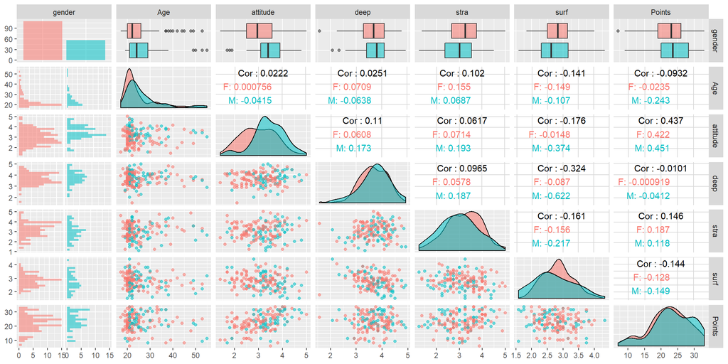

```r
p <- ggpairs(learning2014, mapping = aes(col = gender, alpha = 0.3), lower = list(combo = wrap("facethist", bins = 20)))
p
```

We can see correlations between variables written in black text. For example highest correlation is between attitude and points. In red we have correlations for women and in blue correlations for men. We have also distributions for men and women for all the variables, we see some slight differences between genders but not anything significant. Here have summary of the data

```r
summary(learning2014)
```

```
##  gender       Age           attitude          deep            stra
##  F:110   Min.   :17.00   Min.   :1.400   Min.   :1.583   Min.   :1.250
##  M: 56   1st Qu.:21.00   1st Qu.:2.600   1st Qu.:3.333   1st Qu.:2.625
##          Median :22.00   Median :3.200   Median :3.667   Median :3.188
##          Mean   :25.51   Mean   :3.143   Mean   :3.680   Mean   :3.121
##          3rd Qu.:27.00   3rd Qu.:3.700   3rd Qu.:4.083   3rd Qu.:3.625
##          Max.   :55.00   Max.   :5.000   Max.   :4.917   Max.   :5.000
##       surf           Points
##  Min.   :1.583   Min.   : 7.00
##  1st Qu.:2.417   1st Qu.:19.00
##  Median :2.833   Median :23.00
##  Mean   :2.787   Mean   :22.72
##  3rd Qu.:3.167   3rd Qu.:27.75
##  Max.   :4.333   Max.   :33.00
```

We can see that we have more female participants than men (110 vs. 56).

Next we choose model with three explanatory variables to exaplain exam points. We choose variables with biggest correlation (attitude, strategic- and surface learning)

```r
my_model <- lm(Points ~ attitude + stra + surf, data = learning2014)
summary(my_model)
```

```
##
## Call:
## lm(formula = Points ~ attitude + stra + surf, data = learning2014)
##
## Residuals:
##      Min       1Q   Median       3Q      Max
## -17.1550  -3.4346   0.5156   3.6401  10.8952
##
## Coefficients:
##             Estimate Std. Error t value Pr(>|t|)
## (Intercept)  11.0171     3.6837   2.991  0.00322 **
## attitude      3.3952     0.5741   5.913 1.93e-08 ***
## stra          0.8531     0.5416   1.575  0.11716
## surf         -0.5861     0.8014  -0.731  0.46563
## ---
## Signif. codes:  0 '***' 0.001 '**' 0.01 '*' 0.05 '.' 0.1 ' ' 1
##
## Residual standard error: 5.296 on 162 degrees of freedom
## Multiple R-squared:  0.2074, Adjusted R-squared:  0.1927
## F-statistic: 14.13 on 3 and 162 DF,  p-value: 3.156e-08
```

We continue to remove strategic- and surface learning variables as they were statistically insignificant. New model is:

```r
my_model2 <- lm(Points ~ attitude, data = learning2014)
summary(my_model2)
```

```
##
## Call:
## lm(formula = Points ~ attitude, data = learning2014)
##
## Residuals:
##      Min       1Q   Median       3Q      Max
## -16.9763  -3.2119   0.4339   4.1534  10.6645
##
## Coefficients:
##             Estimate Std. Error t value Pr(>|t|)
## (Intercept)  11.6372     1.8303   6.358 1.95e-09 ***
## attitude      3.5255     0.5674   6.214 4.12e-09 ***
## ---
## Signif. codes:  0 '***' 0.001 '**' 0.01 '*' 0.05 '.' 0.1 ' ' 1
##
## Residual standard error: 5.32 on 164 degrees of freedom
## Multiple R-squared:  0.1906, Adjusted R-squared:  0.1856
## F-statistic: 38.61 on 1 and 164 DF,  p-value: 4.119e-09
```

Both the intercept and variable attitude are now statistically significant at 99.9 % confidence level (1 - p-value). The estimate for attitude is slightly bigger in this second model (One unit change in attitude results to 3.52 change in exam points). Adjusted R-squared is now 0.1856 which means that the model explains around 18 % of the variation of points.

Finally we produce diagnostics plots for Residuals vs Fitted values, Normal QQ-plot and Residuals vs Leverage.

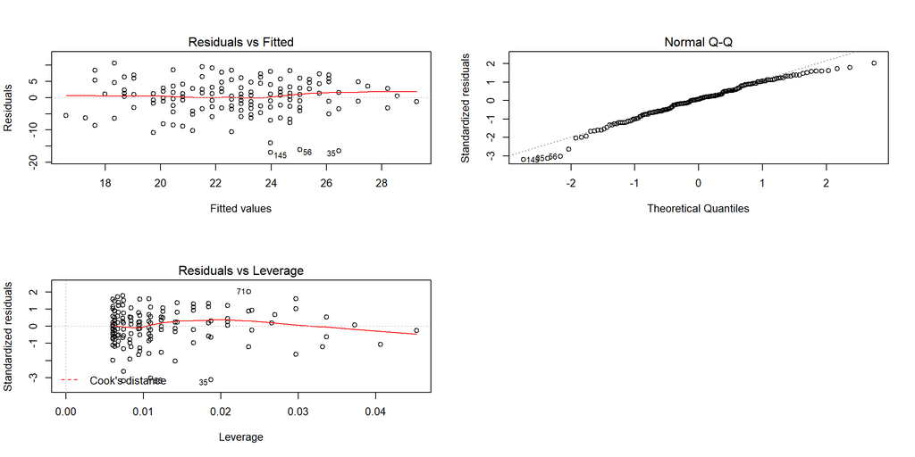

```r
par(mfrow = c(2,2))

plot(my_model2, which = c(1,2,5))
```

# Week 3: Logistic regression

First we read the packages and dataset done earlier

```r
library(dplyr)
library(tidyverse)
library(ggplot2)
library(GGally)
library(cowplot)
library(boot)

alc <- read.csv("~/IODS-project/data/alc.csv", header = T, sep = ",")

alc <- alc[,-1]
```

```r
dim(alc)
```

```
## [1] 382  35
```

```r
colnames(alc)
```

```
##  [1] "school"     "sex"        "age"        "address"    "famsize"
##  [6] "Pstatus"    "Medu"       "Fedu"       "Mjob"       "Fjob"
## [11] "reason"     "nursery"    "internet"   "guardian"   "traveltime"
## [16] "studytime"  "failures"   "schoolsup"  "famsup"     "paid"
## [21] "activities" "higher"     "romantic"   "famrel"     "freetime"
## [26] "goout"      "Dalc"       "Walc"       "health"     "absences"
## [31] "G1"         "G2"         "G3"         "alc_use"    "high_use"
```

We have 382 observations and 35 variables. The variables and observations are from two different datasets that can be accessed from: https://archive.ics.uci.edu/ml/machine-learning-databases/00320/

Meta text can be can accessed here: https://archive.ics.uci.edu/ml/datasets/Student+Performance

From the metatext: “This data approach student achievement in secondary education of two Portuguese schools. The data attributes include student grades, demographic, social and school related features) and it was collected by using school reports and questionnaires.”

We are going to study high/low alcohol consumption and its relationships to “extra-curricular activities”, “romantic relationship”, “quality of family relationships” (from 1 to 5) and “going out with friends” Next we take subset of the variables chosen:

```r
variables <- c("activities", "romantic", "famrel", "goout", "high_use")
new_alc <- select(alc,one_of(variables))
str(new_alc)
```

```
## 'data.frame':    382 obs. of  5 variables:
##  $ activities: Factor w/ 2 levels "no","yes": 1 1 1 2 1 2 1 1 1 2 ...
##  $ romantic  : Factor w/ 2 levels "no","yes": 1 1 1 2 1 1 1 1 1 1 ...
##  $ famrel    : int  4 5 4 3 4 5 4 4 4 5 ...
##  $ goout     : int  4 3 2 2 2 2 4 4 2 1 ...
##  $ high_use  : logi  FALSE FALSE TRUE FALSE FALSE FALSE ...
```

Hypothesis is that social activities and other social attributes correlate negatively with high use of alcohol. Or in other words we hypothise that better social life correlates with less alcohol consumption.

Next we plot the variables with the alcohol use

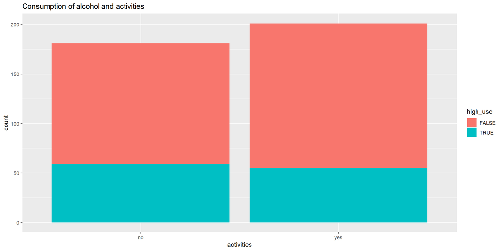

```r
alc_act <- ggplot(data = new_alc, aes(x = activities, fill = high_use)) + geom_bar() + ggtitle("Consumption of alcohol and activities")
alc_act
```

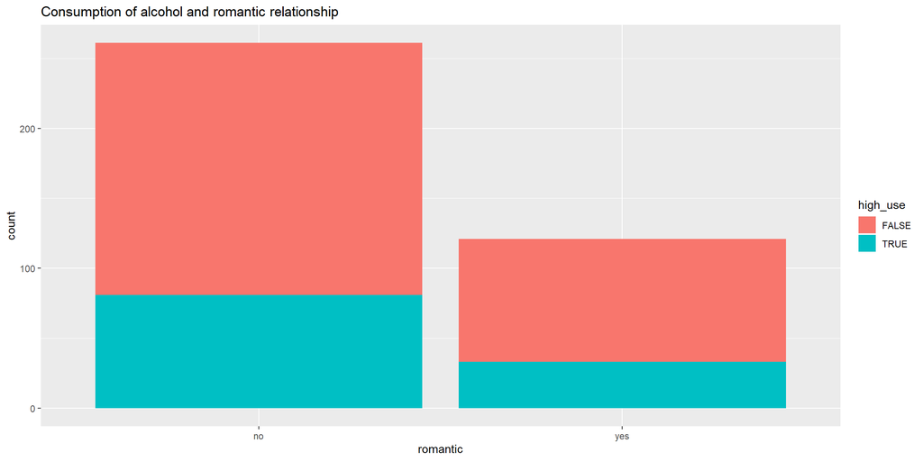

```r
alc_rom <- ggplot(data = new_alc, aes(x = romantic, fill = high_use)) + geom_bar() + ggtitle("Consumption of alcohol and romantic relationship")
alc_rom
```

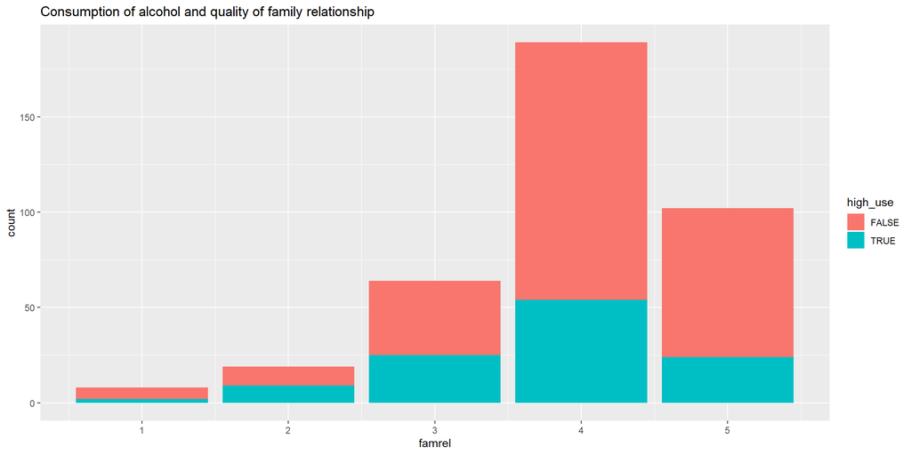

```r
alc_family <- ggplot(data = new_alc, aes(x = famrel, fill = high_use)) + geom_bar() + ggtitle("Consumption of alcohol and quality of family relationship")
alc_family
```

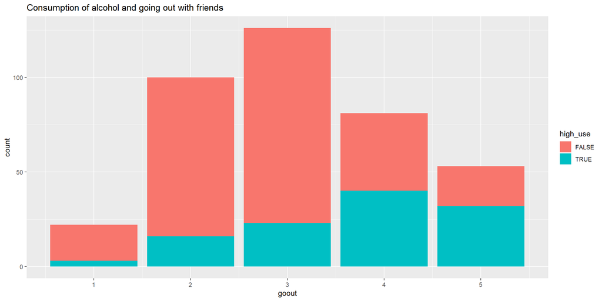

```r
alc_goout <- ggplot(data = new_alc, aes(x = goout, fill = high_use)) + geom_bar() + ggtitle("Consumption of alcohol and going out with friends")
alc_goout
```

Some findings from these plots: 1. Extra-curricular activities correlate with less alcohol consumptions (There is more observations for those who have activities but about same amount for high_use observations) 2. It looks like good family relations correlate with less alcohol consumptions. 3. People who go out with friends look like to be more probable to be high users of alcohol.

Next we take a look at the numbers:

```r
new_alc %>% group_by(activities,high_use) %>% summarise(count = n())
```

```
## # A tibble: 4 x 3
## # Groups:   activities [2]
##   activities high_use count
##   <fct>      <lgl>    <int>
## 1 no         FALSE      122
## 2 no         TRUE        59
## 3 yes        FALSE      146
## 4 yes        TRUE        55
```

1. Extra-curricular activities correlate with less alcohol consumptions

```r
new_alc %>% group_by(romantic,high_use) %>% summarise(count = n())
```

```
## # A tibble: 4 x 3
## # Groups:   romantic [2]
##   romantic high_use count
##   <fct>    <lgl>    <int>
## 1 no       FALSE      180
## 2 no       TRUE        81
## 3 yes      FALSE       88
## 4 yes      TRUE        33
```

2. Those who are not in a romantic relationship are more likely to be high users

```r
new_alc %>% group_by(famrel,high_use) %>% summarise(count = n())
```

```
## # A tibble: 10 x 3
## # Groups:   famrel [5]
##    famrel high_use count
##     <int> <lgl>    <int>
##  1      1 FALSE        6
##  2      1 TRUE         2
##  3      2 FALSE       10
##  4      2 TRUE         9
##  5      3 FALSE       39
##  6      3 TRUE        25
##  7      4 FALSE      135
##  8      4 TRUE        54
##  9      5 FALSE       78
## 10      5 TRUE        24
```

```r
new_alc %>% group_by(goout,high_use) %>% summarise(count = n())
```

```
## # A tibble: 10 x 3
## # Groups:   goout [5]
##    goout high_use count
##    <int> <lgl>    <int>
##  1     1 FALSE       19
##  2     1 TRUE         3
##  3     2 FALSE       84
##  4     2 TRUE        16
##  5     3 FALSE      103
##  6     3 TRUE        23
##  7     4 FALSE       41
##  8     4 TRUE        40
##  9     5 FALSE       21
## 10     5 TRUE        32
```

We make the same observations from the numbers than from the plots

We proceed to make the statistical model

```r
m1 <- glm(high_use ~ activities + romantic + famrel + goout, data = new_alc, family = "binomial")
```

Summary of the model

```r
summary(m1)
```

```
##
## Call:
## glm(formula = high_use ~ activities + romantic + famrel + goout,
##     family = "binomial", data = new_alc)
##
## Deviance Residuals:
##     Min       1Q   Median       3Q      Max
## -1.5238  -0.8258  -0.5829   1.0057   2.4929
##
## Coefficients:
##               Estimate Std. Error z value Pr(>|z|)
## (Intercept)    -1.8234     0.6269  -2.909  0.00363 **
## activitiesyes  -0.3035     0.2443  -1.242  0.21414
## romanticyes    -0.2690     0.2663  -1.010  0.31247
## famrel         -0.3671     0.1343  -2.733  0.00628 **
## goout           0.8027     0.1190   6.743 1.55e-11 ***
## ---
## Signif. codes:  0 '***' 0.001 '**' 0.01 '*' 0.05 '.' 0.1 ' ' 1
##
## (Dispersion parameter for binomial family taken to be 1)
##
##     Null deviance: 465.68  on 381  degrees of freedom
## Residual deviance: 405.44  on 377  degrees of freedom
## AIC: 415.44
##
## Number of Fisher Scoring iterations: 4
```

Only “quality of family relationships” and “going out with friends” are statistically significant. Let’s check if the model is better with only the significant variables.

```r
step(m1, direction = "backward")
```

```
## Start:  AIC=415.44
## high_use ~ activities + romantic + famrel + goout
##
##              Df Deviance    AIC
## - romantic    1   406.47 414.47
## - activities  1   406.98 414.98
## <none>            405.44 415.44
## - famrel      1   412.94 420.94
## - goout       1   459.20 467.20
##
## Step:  AIC=414.47
## high_use ~ activities + famrel + goout
##
##              Df Deviance    AIC
## - activities  1   408.12 414.12
## <none>            406.47 414.47
## - famrel      1   413.68 419.68
## - goout       1   459.94 465.94
##
## Step:  AIC=414.12
## high_use ~ famrel + goout
##
##          Df Deviance    AIC
## <none>        408.12 414.12
## - famrel  1   415.68 419.68
## - goout   1   460.92 464.92
```

```
##
## Call:  glm(formula = high_use ~ famrel + goout, family = "binomial",
##     data = new_alc)
##
## Coefficients:
## (Intercept)       famrel        goout
##     -2.0289      -0.3667       0.7922
##
## Degrees of Freedom: 381 Total (i.e. Null);  379 Residual
## Null Deviance:       465.7
## Residual Deviance: 408.1     AIC: 414.1
```

AIC is smallest with the model with only the significant variables, so we need to remove the others.

```r
m2 <- glm(high_use ~famrel + goout, data = new_alc, family = "binomial")
```

Summary of the model

```r
summary(m2)
```

```
##
## Call:
## glm(formula = high_use ~ famrel + goout, family = "binomial",
##     data = new_alc)
##
## Deviance Residuals:
##     Min       1Q   Median       3Q      Max
## -1.5448  -0.7518  -0.5252   0.9872   2.3530
##
## Coefficients:
##             Estimate Std. Error z value Pr(>|z|)
## (Intercept)  -2.0289     0.6148  -3.300 0.000966 ***
## famrel       -0.3667     0.1338  -2.740 0.006142 **
## goout         0.7922     0.1183   6.698 2.11e-11 ***
## ---
## Signif. codes:  0 '***' 0.001 '**' 0.01 '*' 0.05 '.' 0.1 ' ' 1
##
## (Dispersion parameter for binomial family taken to be 1)
##
##     Null deviance: 465.68  on 381  degrees of freedom
## Residual deviance: 408.12  on 379  degrees of freedom
## AIC: 414.12
##
## Number of Fisher Scoring iterations: 4
```

Coefficients of the model (all are statistically significant at 0.01 risk level)

```r
coef(m2)
```

```
## (Intercept)      famrel       goout
##  -2.0288785  -0.3666676   0.7921642
```

Odds ratios (OR)

```r
OR <- coef(m2) %>% exp
```

Confidence intervals (CI)

```r
CI <- confint(m2) %>% exp
```

Print out the odds ratios with their confidence intervals

```r
cbind(OR, CI)
```

```
##                    OR      2.5 %    97.5 %
## (Intercept) 0.1314829 0.03816207 0.4283774
## famrel      0.6930400 0.53161279 0.8999454
## goout       2.2081701 1.76229526 2.8045361
```

Our result is that one unit positive change in family relations means that you are 0.69 “more likely” to be a high drinker. Similarly one unit positive change in going out with friends means that you are 2.2 more likely to be a high drinker. Family relations supports our initial hypothesis.

Next we make predictions on the basis of our model

Prediction for the probability of high_use

```r
probabilities <- predict(m2, type = "response")

new_alc <- mutate(new_alc, probability = probabilities)
```

Using the probabilities to make a prediction of high_use

```r
new_alc <- mutate(new_alc, prediction = probability > 0.5)
```

Tabulate the target variable versus the predictions

```r
table(high_use = new_alc$high_use, prediction = new_alc$prediction)
```

```
##         prediction
## high_use FALSE TRUE
##    FALSE   243   25
##    TRUE     68   46
```

```r
table(high_use = new_alc$high_use, prediction = new_alc$prediction) %>% prop.table %>% addmargins()
```

```
##         prediction
## high_use      FALSE       TRUE        Sum
##    FALSE 0.63612565 0.06544503 0.70157068
##    TRUE  0.17801047 0.12041885 0.29842932
##    Sum   0.81413613 0.18586387 1.00000000
```

We can see from the table below that the model is predicting correctly High use 243+46 times (out of 243+68+25+46) and wrongly 68+25 times. Model predicts about 25 % of the times wrong -> less than simple guessing.

BONUS questions: 10-fold cross-validation

```r
loss_func <- function(class, prob) {
  n_wrong <- abs(class - prob) > 0.5
  mean(n_wrong)
}
```

Average number of wrong predictions in the (training) data

```r
loss_func(class = new_alc$high_use, prob = new_alc$probability)
```

```
## [1] 0.2434555
```

K-fold cross-validation

```r
library(boot)
cv <- cv.glm(data = new_alc, cost = loss_func, glmfit = m2, K = 10)
```

Average number of wrong predictions in the cross validation

```r
cv$delta[1]
```

```
## [1] 0.2565445
```

The model introduced has similar prediction rate compared to datacamp exercise (0.26)

# Week 4: Clustering and classification

## Overview of the data and data wrangling

We have 506 observations and 14 variables from Boston area

Variables:

rim - per capita crime rate by town.

zn - proportion of residential land zoned for lots over 25,000 sq.ft.

indus - proportion of non-retail business acres per town.

chas-Charles River dummy variable (= 1 if tract bounds river; 0 otherwise).

nox-nitrogen oxides concentration (parts per 10 million).

rm-average number of rooms per dwelling.

age-proportion of owner-occupied units built prior to 1940.

dis-weighted mean of distances to five Boston employment centres.

rad-index of accessibility to radial highways.

tax-full-value property-tax rate per $10,000.

ptratio-pupil-teacher ratio by town.

black-1000(Bk - 0.63)^2 where Bk is the proportion of blacks by town.

lstat-lower status of the population (percent).

medv-median value of owner-occupied homes in $1000s.

First we access the packages and load the data

```r
library(MASS)
library(tidyverse)
library(corrplot)
library(MASS)
library(dplyr)
library(ggplot2)
library(GGally)
data("Boston")
```

Exploring the stucture and summary of the dataset

```r
str(Boston)
```

```
## 'data.frame':    506 obs. of  14 variables:
##  $ crim   : num  0.00632 0.02731 0.02729 0.03237 0.06905 ...
##  $ zn     : num  18 0 0 0 0 0 12.5 12.5 12.5 12.5 ...
##  $ indus  : num  2.31 7.07 7.07 2.18 2.18 2.18 7.87 7.87 7.87 7.87 ...
##  $ chas   : int  0 0 0 0 0 0 0 0 0 0 ...
##  $ nox    : num  0.538 0.469 0.469 0.458 0.458 0.458 0.524 0.524 0.524 0.524 ...
##  $ rm     : num  6.58 6.42 7.18 7 7.15 ...
##  $ age    : num  65.2 78.9 61.1 45.8 54.2 58.7 66.6 96.1 100 85.9 ...
##  $ dis    : num  4.09 4.97 4.97 6.06 6.06 ...
##  $ rad    : int  1 2 2 3 3 3 5 5 5 5 ...
##  $ tax    : num  296 242 242 222 222 222 311 311 311 311 ...
##  $ ptratio: num  15.3 17.8 17.8 18.7 18.7 18.7 15.2 15.2 15.2 15.2 ...
##  $ black  : num  397 397 393 395 397 ...
##  $ lstat  : num  4.98 9.14 4.03 2.94 5.33 ...
##  $ medv   : num  24 21.6 34.7 33.4 36.2 28.7 22.9 27.1 16.5 18.9 ...
```

```r
summary(Boston)
```

```
##       crim                zn             indus            chas
##  Min.   : 0.00632   Min.   :  0.00   Min.   : 0.46   Min.   :0.00000
##  1st Qu.: 0.08204   1st Qu.:  0.00   1st Qu.: 5.19   1st Qu.:0.00000
##  Median : 0.25651   Median :  0.00   Median : 9.69   Median :0.00000
##  Mean   : 3.61352   Mean   : 11.36   Mean   :11.14   Mean   :0.06917
##  3rd Qu.: 3.67708   3rd Qu.: 12.50   3rd Qu.:18.10   3rd Qu.:0.00000
##  Max.   :88.97620   Max.   :100.00   Max.   :27.74   Max.   :1.00000
##       nox               rm             age              dis
##  Min.   :0.3850   Min.   :3.561   Min.   :  2.90   Min.   : 1.130
##  1st Qu.:0.4490   1st Qu.:5.886   1st Qu.: 45.02   1st Qu.: 2.100
##  Median :0.5380   Median :6.208   Median : 77.50   Median : 3.207
##  Mean   :0.5547   Mean   :6.285   Mean   : 68.57   Mean   : 3.795
##  3rd Qu.:0.6240   3rd Qu.:6.623   3rd Qu.: 94.08   3rd Qu.: 5.188
##  Max.   :0.8710   Max.   :8.780   Max.   :100.00   Max.   :12.127
##       rad              tax           ptratio          black
##  Min.   : 1.000   Min.   :187.0   Min.   :12.60   Min.   :  0.32
##  1st Qu.: 4.000   1st Qu.:279.0   1st Qu.:17.40   1st Qu.:375.38
##  Median : 5.000   Median :330.0   Median :19.05   Median :391.44
##  Mean   : 9.549   Mean   :408.2   Mean   :18.46   Mean   :356.67
##  3rd Qu.:24.000   3rd Qu.:666.0   3rd Qu.:20.20   3rd Qu.:396.23
##  Max.   :24.000   Max.   :711.0   Max.   :22.00   Max.   :396.90
##      lstat            medv
##  Min.   : 1.73   Min.   : 5.00
##  1st Qu.: 6.95   1st Qu.:17.02
##  Median :11.36   Median :21.20
##  Mean   :12.65   Mean   :22.53
##  3rd Qu.:16.95   3rd Qu.:25.00
##  Max.   :37.97   Max.   :50.00
```

Plotting the matrix of the variables

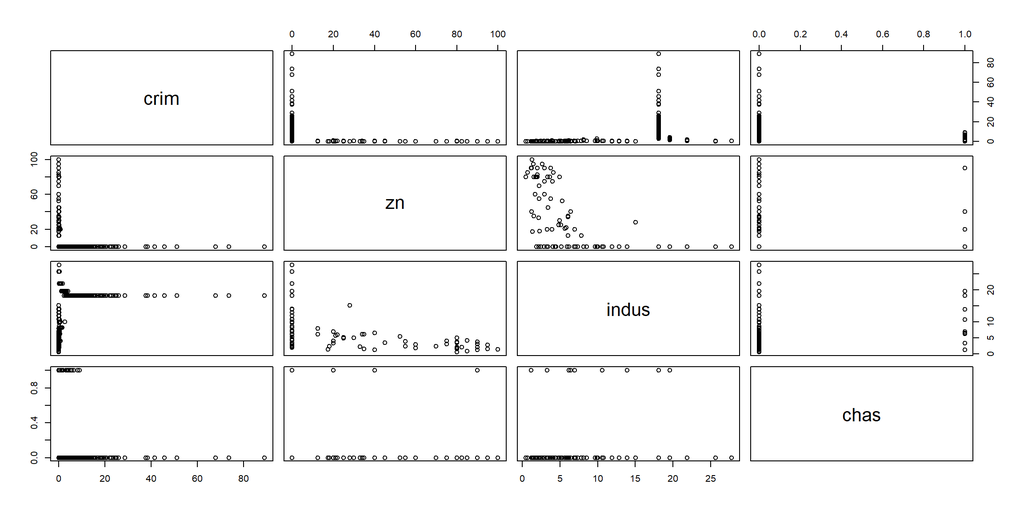

```r
pairs(Boston[1:4])
```

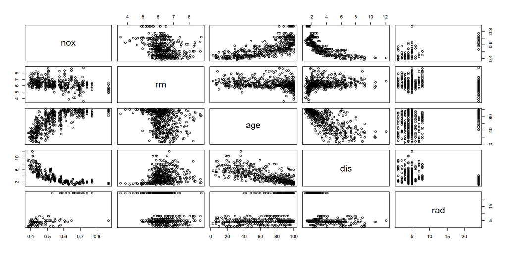

```r
pairs(Boston[5:9])
```

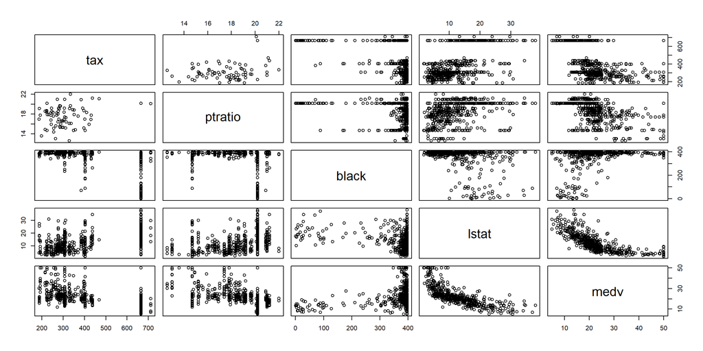

```r
pairs(Boston[10:14])
```

We proceed to calculate the correlation matrix and round it up and then print it

```r
cor_matrix<-cor(Boston) %>% round(2)
cor_matrix
```

```
##          crim    zn indus  chas   nox    rm   age   dis   rad   tax
## crim     1.00 -0.20  0.41 -0.06  0.42 -0.22  0.35 -0.38  0.63  0.58
## zn      -0.20  1.00 -0.53 -0.04 -0.52  0.31 -0.57  0.66 -0.31 -0.31
## indus    0.41 -0.53  1.00  0.06  0.76 -0.39  0.64 -0.71  0.60  0.72
## chas    -0.06 -0.04  0.06  1.00  0.09  0.09  0.09 -0.10 -0.01 -0.04
## nox      0.42 -0.52  0.76  0.09  1.00 -0.30  0.73 -0.77  0.61  0.67
## rm      -0.22  0.31 -0.39  0.09 -0.30  1.00 -0.24  0.21 -0.21 -0.29
## age      0.35 -0.57  0.64  0.09  0.73 -0.24  1.00 -0.75  0.46  0.51
## dis     -0.38  0.66 -0.71 -0.10 -0.77  0.21 -0.75  1.00 -0.49 -0.53
## rad      0.63 -0.31  0.60 -0.01  0.61 -0.21  0.46 -0.49  1.00  0.91
## tax      0.58 -0.31  0.72 -0.04  0.67 -0.29  0.51 -0.53  0.91  1.00
## ptratio  0.29 -0.39  0.38 -0.12  0.19 -0.36  0.26 -0.23  0.46  0.46
## black   -0.39  0.18 -0.36  0.05 -0.38  0.13 -0.27  0.29 -0.44 -0.44
## lstat    0.46 -0.41  0.60 -0.05  0.59 -0.61  0.60 -0.50  0.49  0.54
## medv    -0.39  0.36 -0.48  0.18 -0.43  0.70 -0.38  0.25 -0.38 -0.47
##         ptratio black lstat  medv
## crim       0.29 -0.39  0.46 -0.39
## zn        -0.39  0.18 -0.41  0.36
## indus      0.38 -0.36  0.60 -0.48
## chas      -0.12  0.05 -0.05  0.18
## nox        0.19 -0.38  0.59 -0.43
## rm        -0.36  0.13 -0.61  0.70
## age        0.26 -0.27  0.60 -0.38
## dis       -0.23  0.29 -0.50  0.25
## rad        0.46 -0.44  0.49 -0.38
## tax        0.46 -0.44  0.54 -0.47
## ptratio    1.00 -0.18  0.37 -0.51
## black     -0.18  1.00 -0.37  0.33
## lstat      0.37 -0.37  1.00 -0.74
## medv      -0.51  0.33 -0.74  1.00
```

Then we plot the correlation matrix

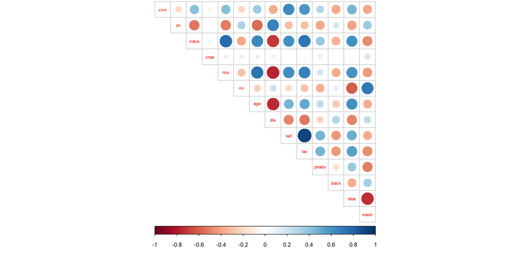

```r
corrplot(cor_matrix, method="circle" ,type = "upper",cl.pos="b", tl.pos = "d", tl.cex =0.6)
```

Next we standadize the dataset

```r
boston_scaled <- scale(Boston)
summary(boston_scaled)
```

```
##       crim                 zn               indus
##  Min.   :-0.419367   Min.   :-0.48724   Min.   :-1.5563
##  1st Qu.:-0.410563   1st Qu.:-0.48724   1st Qu.:-0.8668
##  Median :-0.390280   Median :-0.48724   Median :-0.2109
##  Mean   : 0.000000   Mean   : 0.00000   Mean   : 0.0000
##  3rd Qu.: 0.007389   3rd Qu.: 0.04872   3rd Qu.: 1.0150
##  Max.   : 9.924110   Max.   : 3.80047   Max.   : 2.4202
##       chas              nox                rm               age
##  Min.   :-0.2723   Min.   :-1.4644   Min.   :-3.8764   Min.   :-2.3331
##  1st Qu.:-0.2723   1st Qu.:-0.9121   1st Qu.:-0.5681   1st Qu.:-0.8366
##  Median :-0.2723   Median :-0.1441   Median :-0.1084   Median : 0.3171
##  Mean   : 0.0000   Mean   : 0.0000   Mean   : 0.0000   Mean   : 0.0000
##  3rd Qu.:-0.2723   3rd Qu.: 0.5981   3rd Qu.: 0.4823   3rd Qu.: 0.9059
##  Max.   : 3.6648   Max.   : 2.7296   Max.   : 3.5515   Max.   : 1.1164
##       dis               rad               tax             ptratio
##  Min.   :-1.2658   Min.   :-0.9819   Min.   :-1.3127   Min.   :-2.7047
##  1st Qu.:-0.8049   1st Qu.:-0.6373   1st Qu.:-0.7668   1st Qu.:-0.4876
##  Median :-0.2790   Median :-0.5225   Median :-0.4642   Median : 0.2746
##  Mean   : 0.0000   Mean   : 0.0000   Mean   : 0.0000   Mean   : 0.0000
##  3rd Qu.: 0.6617   3rd Qu.: 1.6596   3rd Qu.: 1.5294   3rd Qu.: 0.8058
##  Max.   : 3.9566   Max.   : 1.6596   Max.   : 1.7964   Max.   : 1.6372
##      black             lstat              medv
##  Min.   :-3.9033   Min.   :-1.5296   Min.   :-1.9063
##  1st Qu.: 0.2049   1st Qu.:-0.7986   1st Qu.:-0.5989
##  Median : 0.3808   Median :-0.1811   Median :-0.1449
##  Mean   : 0.0000   Mean   : 0.0000   Mean   : 0.0000
##  3rd Qu.: 0.4332   3rd Qu.: 0.6024   3rd Qu.: 0.2683
##  Max.   : 0.4406   Max.   : 3.5453   Max.   : 2.9865
```

All variables have now zero as a mean value. We proceed to wrangle the crime rate variable:

```r
boston_scaled <- as.data.frame(boston_scaled)
summary(boston_scaled$crim)
```

```
##      Min.   1st Qu.    Median      Mean   3rd Qu.      Max.
## -0.419367 -0.410563 -0.390280  0.000000  0.007389  9.924110
```

```r
bins <- quantile(boston_scaled$crim)
crime <- cut(boston_scaled$crim, breaks = bins, include.lowest = TRUE, labels = c("low", "med_low", "med_high", "high"))
table(crime)
```

```
## crime
##      low  med_low med_high     high
##      127      126      126      127
```

```r
boston_scaled <- dplyr::select(boston_scaled, -crim)
boston_scaled <- data.frame(boston_scaled, crime)
```

Now we have a new categorical variable of the crime rate in the boston dataset. Old crime rate variable has also been dropped. The next step is to divide the dataset to train and test set:

```r
n <- nrow(boston_scaled)
ind <- sample(n,  size = n * 0.8)
train <- boston_scaled[ind,]
test <- boston_scaled[-ind,]
correct_classes <- test$crime
test <- dplyr::select(test, -crime)
```

## Linear discriminant analysis

Now that we have finished data wrangling, we can proceed to linear discriminant analysis on the train set. Categorical crime rate is target variable and other variables in the dataset are predictor variables.

```r
lda.fit <- lda(crime ~., data = train)

lda.fit
```

```
## Call:
## lda(crime ~ ., data = train)
##
## Prior probabilities of groups:
##       low   med_low  med_high      high
## 0.2623762 0.2425743 0.2376238 0.2574257
##
## Group means:
##                   zn      indus        chas        nox           rm
## low       0.94186286 -0.8910903 -0.08661679 -0.8787712  0.484304589
## med_low  -0.07684474 -0.3131039 -0.07145661 -0.5862283 -0.099528323
## med_high -0.38719354  0.2041763  0.17879700  0.3522280  0.005546211
## high     -0.48724019  1.0149946 -0.08304540  1.0948809 -0.422622879
##                 age        dis        rad        tax     ptratio
## low      -0.8878135  0.8604701 -0.7012552 -0.7666492 -0.38471734
## med_low  -0.2995519  0.3930925 -0.5330315 -0.4759589 -0.09917906
## med_high  0.4199435 -0.3535322 -0.4243862 -0.3114279 -0.25227360
## high      0.8248763 -0.8502633  1.6596029  1.5294129  0.80577843
##               black      lstat         medv
## low       0.3781715 -0.7737271  0.574034802
## med_low   0.3148360 -0.1370919  0.004865085
## med_high  0.0779255  0.0659273  0.099046794
## high     -0.8644000  0.9248671 -0.754221374
##
## Coefficients of linear discriminants:
##                 LD1         LD2         LD3
## zn       0.10481211  0.73572376 -0.91379865
## indus    0.01346661 -0.19172292  0.18406982
## chas    -0.01323292 -0.03438530  0.04092955
## nox      0.36489120 -0.62427059 -1.55208758
## rm       0.02377598  0.02090275 -0.18100937
## age      0.27192732 -0.37047511  0.03285112
## dis     -0.07464097 -0.29039386  0.19722070
## rad      3.61460160  1.12736630  0.04824447
## tax      0.11541337 -0.31315277  0.68667139
## ptratio  0.15669555  0.12984165 -0.40703400
## black   -0.14023982 -0.00625450  0.14229272
## lstat    0.18171335 -0.28025528  0.21151283
## medv     0.06614879 -0.37357176 -0.35225503
##
## Proportion of trace:
##    LD1    LD2    LD3
## 0.9638 0.0267 0.0095
```

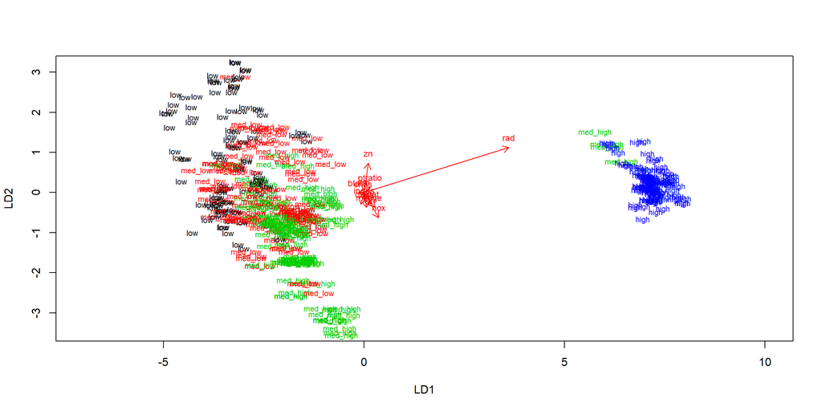

```r
lda.arrows <- function(x, myscale = 1, arrow_heads = 0.1, color = "red", tex = 0.75, choices = c(1,2)){
  heads <- coef(x)
  arrows(x0 = 0, y0 = 0,
         x1 = myscale * heads[,choices[1]],
         y1 = myscale * heads[,choices[2]], col=color, length = arrow_heads)
  text(myscale * heads[,choices], labels = row.names(heads),
       cex = tex, col=color, pos=3)
}

classes <- as.numeric(train$crime)

plot(lda.fit, dimen = 2, col=classes, pch = classes)
lda.arrows(lda.fit, myscale = 1)
```

Next we predict the classes with the LDA model on the test data and cross tabulate the results with the crime categories from the test set. Earlier we saved the crime categories from the test set and removed the categorical crime variable from the test dataset.

```r
lda.pred <- predict(lda.fit, newdata = test)
table(correct = correct_classes, predicted = lda.pred$class)
```

```
##           predicted
## correct    low med_low med_high high
##   low       11      10        0    0
##   med_low    9      13        6    0
##   med_high   1       8       19    2
##   high       0       0        1   22
```

Firstly model predicts very well high crime rate. The model predictor performs badly on the second lowest crime rate.

## K-means algorithm

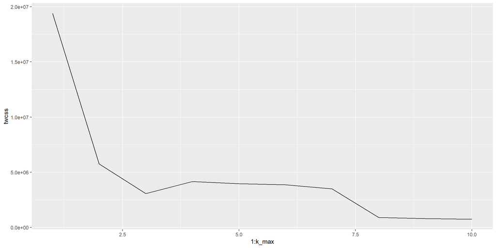

```r
boston_scaled <- as.data.frame(boston_scaled)
set.seed(123)
k_max <- 10
twcss <- sapply(1:k_max, function(k){kmeans(Boston, k)$tot.withinss})
qplot(x = 1:k_max, y = twcss, geom = 'line')
```

We can see dramatic drop at the second value -> two clusters is the way to go.

```r
km <-kmeans(Boston, centers = 2)

class(km$cluster)
```

```
## [1] "integer"
```

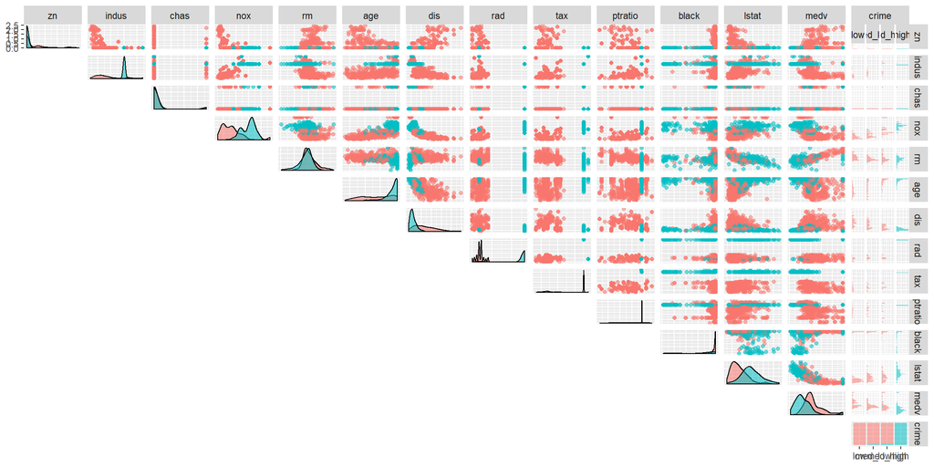

```r
ggpairs(boston_scaled, mapping = aes(col = as.factor(km$cluster), alpha = 0.3), lower = "blank", upper = list(continuous = "points", combo =
                                                                                                             "facethist", discrete = "facetbar", na = "na"))
```

In most cases two clusters divides the observations well enough.

# Week 5: Dimensionality reduction techniques

## Overview of the data and data wrangling

Packages for the session

```r
rm(list=ls())
library(GGally)
library(ggplot2)
library(dplyr)
library(corrplot)
library(tidyr)
```

We read the data and take a look at the summary

```r
human <- read.csv("~/IODS-project/data/human.csv", sep  =",", header = T, row.names = 1)
names(human)
```

```
## [1] "life_exp"               "exp_education"
## [3] "gni"                    "maternal_mortality_rat"
## [5] "adolescent_birth_rat"   "female_parliament"
## [7] "sec_ed_rat"             "lfpr_ratio"
```

```r
summary(human)
```

```
##     life_exp     exp_education        gni         maternal_mortality_rat
##  Min.   :49.00   Min.   : 5.40   Min.   :   581   Min.   :   1.0
##  1st Qu.:66.30   1st Qu.:11.25   1st Qu.:  4198   1st Qu.:  11.5
##  Median :74.20   Median :13.50   Median : 12040   Median :  49.0
##  Mean   :71.65   Mean   :13.18   Mean   : 17628   Mean   : 149.1
##  3rd Qu.:77.25   3rd Qu.:15.20   3rd Qu.: 24512   3rd Qu.: 190.0
##  Max.   :83.50   Max.   :20.20   Max.   :123124   Max.   :1100.0
##  adolescent_birth_rat female_parliament   sec_ed_rat       lfpr_ratio
##  Min.   :  0.60       Min.   : 0.00     Min.   :0.1717   Min.   :0.1857
##  1st Qu.: 12.65       1st Qu.:12.40     1st Qu.:0.7264   1st Qu.:0.5984
##  Median : 33.60       Median :19.30     Median :0.9375   Median :0.7535
##  Mean   : 47.16       Mean   :20.91     Mean   :0.8529   Mean   :0.7074
##  3rd Qu.: 71.95       3rd Qu.:27.95     3rd Qu.:0.9968   3rd Qu.:0.8535
##  Max.   :204.80       Max.   :57.50     Max.   :1.4967   Max.   :1.0380
```

We have 155 observations and 8 variables from OECD’s Human development report. Link to more information: http://hdr.undp.org/en/content/human-development-index-hdi Next we look graphically at the relations

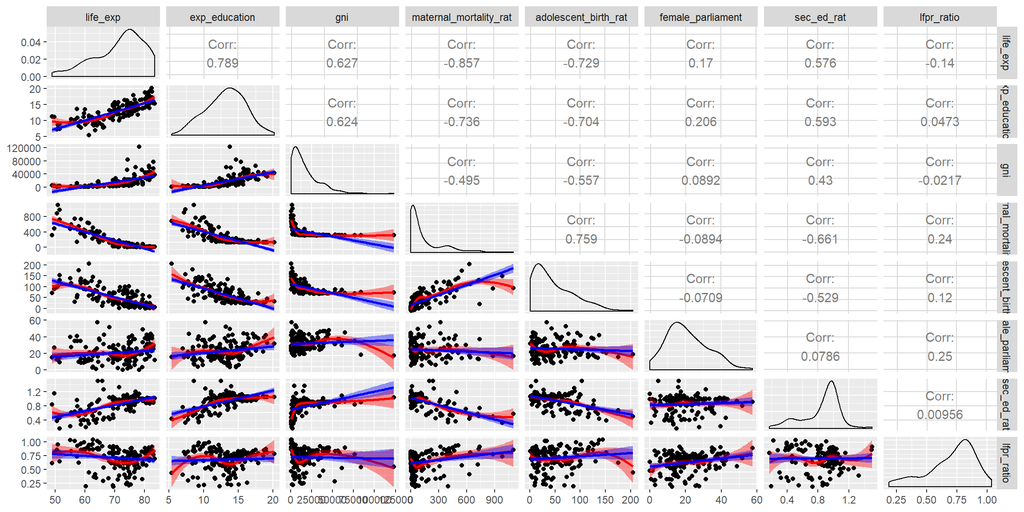

```r
my_fn <- function(data, mapping, ...){
  p <- ggplot(data = data, mapping = mapping) +
    geom_point() +
    geom_smooth(method=loess, fill="red", color="red", ...) +
    geom_smooth(method=lm, fill="blue", color="blue", ...)
  p
}
ggpairs(human, lower = list(continuous = my_fn))
```

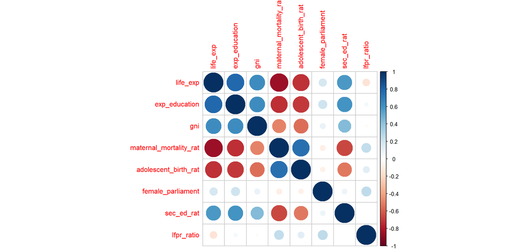

```r
cor(human) %>% corrplot
```

Many of the variables are not perfectly normally distributed and are skewed either to the right or left. There is some obvious (negative) correlations for example maternal mortality ratio and life expectancy.

## Principal component analysis PCA (Not standardized data & standardized data)

We proceed to PCA for the not standardized human data.

```r
pca_human_not_std <- prcomp(human)
sum_pca_human_not_std <- summary(pca_human_not_std)
pca_pr_not_std <- round(100*sum_pca_human_not_std$importance[2, ], digits = 3)
pca_pr_not_std
```

```
##   PC1   PC2   PC3   PC4   PC5   PC6   PC7   PC8
## 99.99  0.01  0.00  0.00  0.00  0.00  0.00  0.00
```

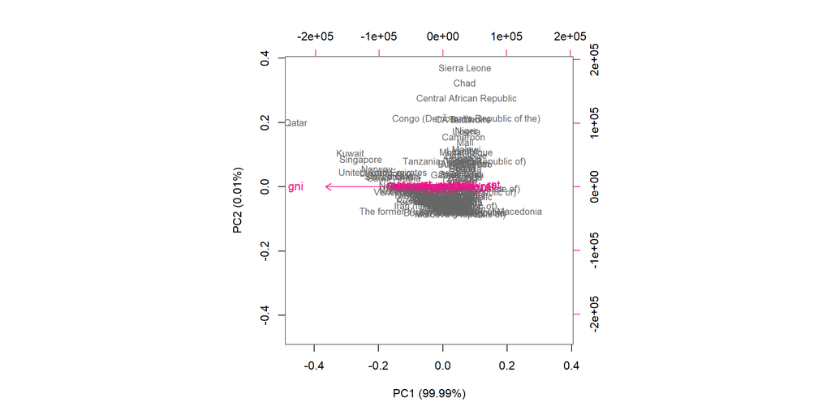

```r
pc_lab_not_std <- paste0(names(pca_pr_not_std), " (", pca_pr_not_std, "%)")
biplot(pca_human_not_std, cex = c(0.8, 1), col = c("grey40", "deeppink2"), xlab = pc_lab_not_std[1], ylab = pc_lab_not_std[2])
```

There is two principal components catching any variance. The first principal component catches 99.99% of the variance.

How do things change when we standardize?

```r
human_std <- scale(human)
pca_human <- prcomp(human_std)
sum_pca_human <- summary(pca_human)
pca_pr <- round(100*sum_pca_human$importance[2, ], digits = 3)
pca_pr
```

```
##    PC1    PC2    PC3    PC4    PC5    PC6    PC7    PC8
## 53.605 16.237  9.571  7.583  5.477  3.595  2.634  1.298
```

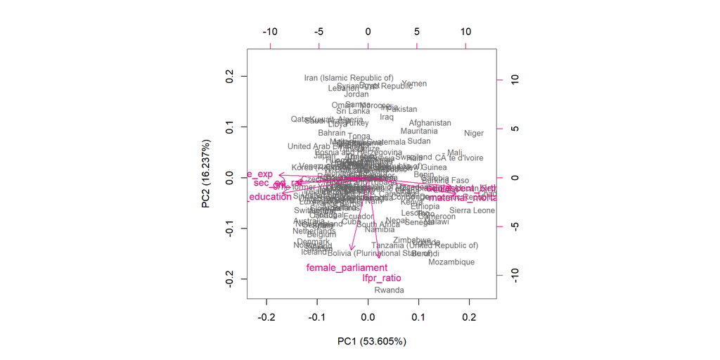

```r
pc_lab <- paste0(names(pca_pr), " (", pca_pr, "%)")

biplot(pca_human, cex = c(0.8, 1), col = c("grey40", "deeppink2"), xlab = pc_lab[1], ylab = pc_lab[2])
```

We see that variance captured changes dramatically when the human data is standardized and for meaningful research it is necessary. Now all eight principal components catch variance.First component catches only 53,6 % now. X-axis is representing PC1 and y-axis is representing PC2. The direction and lenght of arrows represents how increase in each variable affects where the observation will be plotted. The points where countries are is the linear combination of the “arrows”. We can see that the rich countries are on the left side and poorer on the right (PC1). The vertical axis tells about countries equality.

## Tea time

For tea time we need to add factominer library. Let’s read the data.

```r
library(FactoMineR)
tea <- read.table("http://factominer.free.fr/book/tea.csv",header=TRUE,sep=";")
colnames(tea)
```

```
##  [1] "breakfast"         "afternoon.tea"     "evening"
##  [4] "after.lunch"       "after.dinner"      "anytime"
##  [7] "home"              "work"              "tearoom"
## [10] "friends"           "restaurant"        "pub"
## [13] "variety"           "how"               "sugar"
## [16] "format"            "place.of.purchase" "type"
## [19] "sex"               "profession"        "sport"
## [22] "age"               "age_Q"             "frequency"
## [25] "exotic"            "spirituality"      "good.for.health"
## [28] "diuretic"          "friendliness"      "iron.absorption"
## [31] "feminine"          "refined"           "slimming"
## [34] "stimulant"         "relaxant"          "no.effect.health"
```

```r
str(tea)
```

```
## 'data.frame':    300 obs. of  36 variables:
##  $ breakfast        : Factor w/ 2 levels "breakfast","not.breakfast": 1 1 2 2 1 2 1 2 1 1 ...
##  $ afternoon.tea    : Factor w/ 2 levels "afternoon.tea",..: 2 2 1 2 2 2 1 1 1 2 ...
##  $ evening          : Factor w/ 2 levels "evening","not.evening": 2 2 1 2 1 2 2 1 2 1 ...
##  $ after.lunch      : Factor w/ 2 levels "after.lunch",..: 2 2 2 2 2 2 2 2 2 2 ...
##  $ after.dinner     : Factor w/ 2 levels "after.dinner",..: 2 2 1 1 2 1 2 2 2 2 ...
##  $ anytime          : Factor w/ 2 levels "anytime","not.anytime": 2 2 2 2 1 2 2 2 2 2 ...
##  $ home             : Factor w/ 2 levels "home","not.home": 1 1 1 1 1 1 1 1 1 1 ...
##  $ work             : Factor w/ 2 levels "not.work","work": 1 1 2 1 1 1 1 1 1 1 ...
##  $ tearoom          : Factor w/ 2 levels "not.tearoom",..: 1 1 1 1 1 1 1 1 1 2 ...
##  $ friends          : Factor w/ 2 levels "friends","not.friends": 2 2 1 2 2 2 1 2 2 2 ...
##  $ restaurant       : Factor w/ 2 levels "not.restaurant",..: 1 1 2 1 1 1 1 1 1 1 ...
##  $ pub              : Factor w/ 2 levels "not.pub","pub": 1 1 1 1 1 1 1 1 1 1 ...
##  $ variety          : Factor w/ 3 levels "black","flavoured",..: 1 1 2 2 2 2 2 1 2 1 ...
##  $ how              : Factor w/ 4 levels "lemon","milk",..: 3 2 3 3 3 3 3 2 2 3 ...
```

[output cut: 22 more lines]

```r
summary(tea)
```

```
##          breakfast           afternoon.tea        evening
##  breakfast    :144   afternoon.tea  :169   evening    :103
##  not.breakfast:156   Not.afternoon.t:131   not.evening:197
##
##
##
##
##
##           after.lunch            after.dinner        anytime
##  after.lunch    : 44   after.dinner    : 21   anytime    :103
##  not.after.lunch:256   not.after.dinner:279   not.anytime:197
##
##
##
##
##
##        home           work            tearoom           friends
##  home    :291   not.work:213   not.tearoom:242   friends    :196
##  not.home:  9   work    : 87   tearoom    : 58   not.friends:104
##
##
##
##
##
##           restaurant       pub           variety               how
##  not.restaurant:221   not.pub:237   black    : 74   lemon        : 33
##  restaurant    : 79   pub    : 63   flavoured:193   milk         : 63
##                                     green    : 33   nothing.added:195
##                                                     other        :  9
##
##
##
##        sugar              format                  place.of.purchase
##  not.sugar:155   loose       : 36   specialist.shop        : 30
##  sugar    :145   sachet      :170   supermarket            :192
##                  sachet+loose: 94   supermarket+specialist.: 78
##
##
##
##
```

[output cut: 33 more lines]

```
##  not.refined: 85   not.slimming:255   not.stimulant:184
##  refined    :215   slimming    : 45   stimulant    :116
##
##
##
##
##
##          relaxant                    no.effect.health
##  not.relaxant:113   no.effect.health         : 66
##  relaxant    :187   not.without.effect.health:234
##
##
##
##
##
```

We have 300 observations from 36 variables. Next we observe variables graphically. We include only variables: “variety”, “how”, “format”, “sugar”, “place.of.purchase”, “after.lunch” for our visualization to make it clearer.

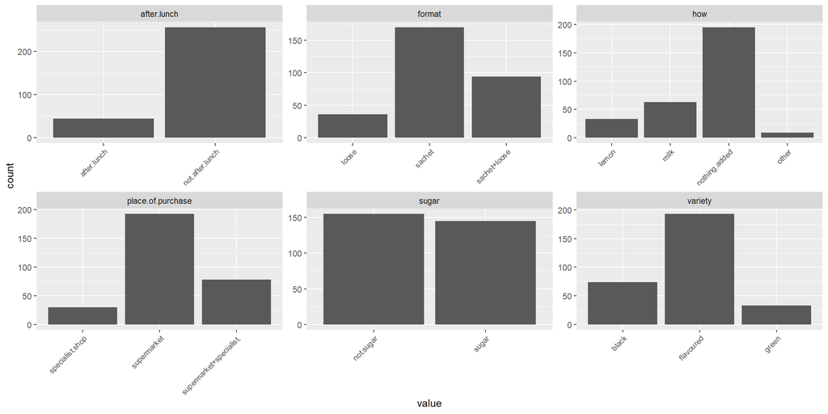

```r
tea_time <- dplyr::select(tea, variety, how, format, sugar, place.of.purchase, after.lunch)
gather(tea_time) %>% ggplot(aes(value)) + facet_wrap("key", scales = "free") + geom_bar() + theme(axis.text.x = element_text(angle = 45, hjust = 1, size = 8))
```

We proceed to do multiple correspondence analysis and visualize it.

```r
# multiple correspondence analysis
mca <- MCA(tea_time, graph = FALSE)

# summary of the model
summary(mca)
```

```
##
## Call:
## MCA(X = tea_time, graph = FALSE)
##
##
## Eigenvalues
##                        Dim.1   Dim.2   Dim.3   Dim.4   Dim.5   Dim.6
## Variance               0.279   0.261   0.219   0.189   0.177   0.156
## % of var.             15.238  14.232  11.964  10.333   9.667   8.519
## Cumulative % of var.  15.238  29.471  41.435  51.768  61.434  69.953
##                        Dim.7   Dim.8   Dim.9  Dim.10  Dim.11
## Variance               0.144   0.141   0.117   0.087   0.062
## % of var.              7.841   7.705   6.392   4.724   3.385
## Cumulative % of var.  77.794  85.500  91.891  96.615 100.000
##
## Individuals (the 10 first)
##                  Dim.1    ctr   cos2    Dim.2    ctr   cos2    Dim.3
## 1             | -0.298  0.106  0.086 | -0.328  0.137  0.105 | -0.327
## 2             | -0.237  0.067  0.036 | -0.136  0.024  0.012 | -0.695
## 3             | -0.369  0.162  0.231 | -0.300  0.115  0.153 | -0.202
## 4             | -0.530  0.335  0.460 | -0.318  0.129  0.166 |  0.211
## 5             | -0.369  0.162  0.231 | -0.300  0.115  0.153 | -0.202
## 6             | -0.369  0.162  0.231 | -0.300  0.115  0.153 | -0.202
## 7             | -0.369  0.162  0.231 | -0.300  0.115  0.153 | -0.202
## 8             | -0.237  0.067  0.036 | -0.136  0.024  0.012 | -0.695
## 9             |  0.143  0.024  0.012 |  0.871  0.969  0.435 | -0.067
## 10            |  0.476  0.271  0.140 |  0.687  0.604  0.291 | -0.650
##                  ctr   cos2
## 1              0.163  0.104 |
## 2              0.735  0.314 |
## 3              0.062  0.069 |
## 4              0.068  0.073 |
## 5              0.062  0.069 |
## 6              0.062  0.069 |
## 7              0.062  0.069 |
## 8              0.735  0.314 |
## 9              0.007  0.003 |
## 10             0.643  0.261 |
##
## Categories (the 10 first)
```

[output cut: 16 more lines]

```
## milk            2.422 |   0.013   0.003   0.000   0.116 |
## nothing.added  -6.164 |  -0.113   0.627   0.024  -2.655 |
## other           5.534 |  -2.524  14.526   0.197  -7.676 |
## loose          -6.482 |   0.257   0.602   0.009   1.640 |
## sachet         -6.941 |  -0.065   0.183   0.006  -1.287 |
## sachet+loose   11.956 |   0.019   0.009   0.000   0.226 |
##
## Categorical variables (eta2)
##                     Dim.1 Dim.2 Dim.3
## variety           | 0.126 0.108 0.410 |
## how               | 0.076 0.190 0.394 |
## format            | 0.708 0.522 0.010 |
## sugar             | 0.065 0.001 0.336 |
## place.of.purchase | 0.702 0.681 0.055 |
## after.lunch       | 0.000 0.064 0.111 |
```

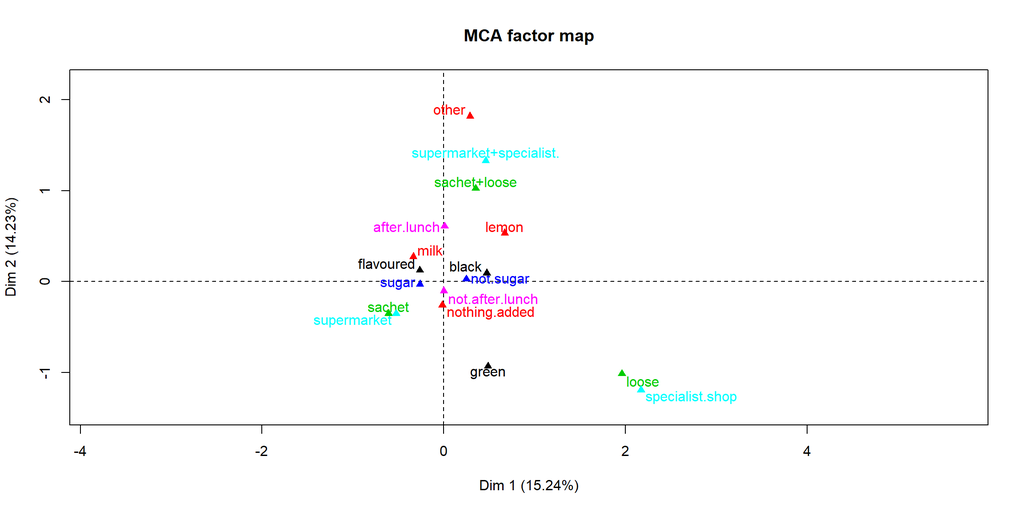

```r
# visualize MCA
plot(mca, invisible=c("ind"), habillage = "quali")
```

Dimensions 1 (15.24 %) and 2 (14.23 %) capture almost 30% of the variance. ***

# Week 6: Analysis of longitudinal data

First packages for the session.

```r
library(dplyr)
library(tidyr)
library(ggplot2)
library(lme4)
```

Data wrangling is also here because of issues with rmarkdown. You can ignore it.

```r
BPRS <- read.csv("https://raw.githubusercontent.com/KimmoVehkalahti/MABS/master/Examples/data/BPRS.txt", stringsAsFactors = F, sep = "", header = T)
RATS <- read.csv("https://raw.githubusercontent.com/KimmoVehkalahti/MABS/master/Examples/data/rats.txt", stringsAsFactors = F, sep = "\t", header = T)
BPRS$treatment <- as.factor(BPRS$treatment)
BPRS$subject <- as.factor(BPRS$subject)
RATS$ID <- as.factor(RATS$ID)
RATS$Group <- as.factor(RATS$Group)
BPRSL <-  BPRS %>% gather(key = weeks, value = bprs, -treatment, -subject) %>% mutate(week = as.integer(substr(weeks, 5, 5)))
RATSL <- RATS %>% gather(key = WD, value = Weight, -ID, -Group) %>% mutate(Time = as.integer(substr(WD, 3,4)))
```

## RATS case

We have the data set about rats and their weights in long form, let’s plot it.

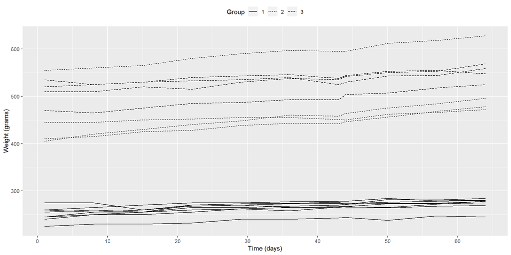

```r
ggplot(RATSL, aes(x = Time, y = Weight, group = ID, linetype = Group)) + geom_line() +scale_x_continuous(name = "Time (days)", breaks = seq(0, 60, 10)) + scale_y_continuous(name = "Weight (grams)") + theme(legend.position = "top")
```

It would seem that the rats are getting bigger as time goes by. There is also differences between groups. Let’s make a regression model where weight is predicted by time and group.

```r
RATS_reg <- lm(Weight ~ Time + Group, data = RATSL)
summary(RATS_reg)
```

```
##
## Call:
## lm(formula = Weight ~ Time + Group, data = RATSL)
##
## Residuals:
##     Min      1Q  Median      3Q     Max
## -60.643 -24.017   0.697  10.837 125.459
##
## Coefficients:
##             Estimate Std. Error t value Pr(>|t|)
## (Intercept) 244.0689     5.7725  42.281  < 2e-16 ***
## Time          0.5857     0.1331   4.402 1.88e-05 ***
## Group2      220.9886     6.3402  34.855  < 2e-16 ***
## Group3      262.0795     6.3402  41.336  < 2e-16 ***
## ---
## Signif. codes:  0 '***' 0.001 '**' 0.01 '*' 0.05 '.' 0.1 ' ' 1
##
## Residual standard error: 34.34 on 172 degrees of freedom
## Multiple R-squared:  0.9283, Adjusted R-squared:  0.9271
## F-statistic: 742.6 on 3 and 172 DF,  p-value: < 2.2e-16
```

All variables are statistically significant (and positive). However there is an issue. It is likely that the measurement is not independet of the previous measurement. Therefore we add a random intercept which allows for each rat to differ in intercept from other rats.

```r
RATS_ref <- lmer(Weight ~ Time + Group + (1 | ID), data = RATSL, REML = FALSE)
summary(RATS_ref)
```

```
## Linear mixed model fit by maximum likelihood  ['lmerMod']
## Formula: Weight ~ Time + Group + (1 | ID)
##    Data: RATSL
##
##      AIC      BIC   logLik deviance df.resid
##   1333.2   1352.2   -660.6   1321.2      170
##
## Scaled residuals:
##     Min      1Q  Median      3Q     Max
## -3.5386 -0.5581 -0.0494  0.5693  3.0990
##
## Random effects:
##  Groups   Name        Variance Std.Dev.
##  ID       (Intercept) 1085.92  32.953
##  Residual               66.44   8.151
## Number of obs: 176, groups:  ID, 16
##
## Fixed effects:
##              Estimate Std. Error t value
## (Intercept) 244.06890   11.73107   20.80
## Time          0.58568    0.03158   18.54
## Group2      220.98864   20.23577   10.92
## Group3      262.07955   20.23577   12.95
##
## Correlation of Fixed Effects:
##        (Intr) Time   Group2
## Time   -0.090
## Group2 -0.575  0.000
## Group3 -0.575  0.000  0.333
```

We also need to take the slope to account. After these changes the model should take account the rats individual differences and the effect of time.

```r
RATS_ref1 <- lmer(Weight ~ Time + Group + (Time | ID), data = RATSL, REML = FALSE)
anova(RATS_ref1, RATS_ref)
```

```
## Data: RATSL
## Models:
## RATS_ref: Weight ~ Time + Group + (1 | ID)
## RATS_ref1: Weight ~ Time + Group + (Time | ID)
##           Df    AIC    BIC  logLik deviance  Chisq Chi Df Pr(>Chisq)
## RATS_ref   6 1333.2 1352.2 -660.58   1321.2
## RATS_ref1  8 1194.2 1219.6 -589.11   1178.2 142.94      2  < 2.2e-16 ***
## ---
## Signif. codes:  0 '***' 0.001 '**' 0.01 '*' 0.05 '.' 0.1 ' ' 1
```

AIC, BIC and P-value tell us that the model which takes account individual differences and effect of time is better. Finally let’s make a model with Group*Time interaction.

```r
RATS_ref2 <- lmer(Weight ~ Time * Group + (Time | ID), data = RATSL, REML = FALSE)
anova(RATS_ref2, RATS_ref1)
```

```
## Data: RATSL
## Models:
## RATS_ref1: Weight ~ Time + Group + (Time | ID)
## RATS_ref2: Weight ~ Time * Group + (Time | ID)
##           Df    AIC    BIC  logLik deviance  Chisq Chi Df Pr(>Chisq)
## RATS_ref1  8 1194.2 1219.6 -589.11   1178.2
## RATS_ref2 10 1185.9 1217.6 -582.93   1165.9 12.361      2    0.00207 **
## ---
## Signif. codes:  0 '***' 0.001 '**' 0.01 '*' 0.05 '.' 0.1 ' ' 1
```

Model with the group*time interaction is the best model so far.

```r
summary(RATS_ref2)
```

```
## Linear mixed model fit by maximum likelihood  ['lmerMod']
## Formula: Weight ~ Time * Group + (Time | ID)
##    Data: RATSL
##
##      AIC      BIC   logLik deviance df.resid
##   1185.9   1217.6   -582.9   1165.9      166
##
## Scaled residuals:
##     Min      1Q  Median      3Q     Max
## -3.2666 -0.4249  0.0726  0.6034  2.7510
##
## Random effects:
##  Groups   Name        Variance  Std.Dev. Corr
##  ID       (Intercept) 1.105e+03 33.2488
##           Time        4.924e-02  0.2219  -0.15
##  Residual             1.975e+01  4.4440
## Number of obs: 176, groups:  ID, 16
##
## Fixed effects:
##              Estimate Std. Error t value
## (Intercept) 251.65165   11.79308  21.339
## Time          0.35964    0.08215   4.378
## Group2      200.66549   20.42622   9.824
## Group3      252.07168   20.42622  12.341
## Time:Group2   0.60584    0.14228   4.258
## Time:Group3   0.29834    0.14228   2.097
##
## Correlation of Fixed Effects:
##             (Intr) Time   Group2 Group3 Tm:Gr2
## Time        -0.160
## Group2      -0.577  0.092
## Group3      -0.577  0.092  0.333
## Time:Group2  0.092 -0.577 -0.160 -0.053
## Time:Group3  0.092 -0.577 -0.053 -0.160  0.333
## convergence code: 0
## Model failed to converge with max|grad| = 0.00701626 (tol = 0.002, component 1)
```

We can see the effects of each variable under the “Fixed effects” table.

## BPRS case

Let’s take a glimpse at the BPRSL data (we add week number as a variable)

```r
BPRSL <-  BPRSL %>% mutate(week = as.integer(substr(weeks,5,5)))

glimpse(BPRSL)
```

```
## Observations: 360
## Variables: 5
## $ treatment <fct> 1, 1, 1, 1, 1, 1, 1, 1, 1, 1, 1, 1, 1, 1, 1, 1, 1, 1...
## $ subject   <fct> 1, 2, 3, 4, 5, 6, 7, 8, 9, 10, 11, 12, 13, 14, 15, 1...
## $ weeks     <chr> "week0", "week0", "week0", "week0", "week0", "week0"...
## $ bprs      <int> 42, 58, 54, 55, 72, 48, 71, 30, 41, 57, 30, 55, 36, ...
## $ week      <int> 0, 0, 0, 0, 0, 0, 0, 0, 0, 0, 0, 0, 0, 0, 0, 0, 0, 0...
```

We clearly have longitudal data. Next step is to plot the data.

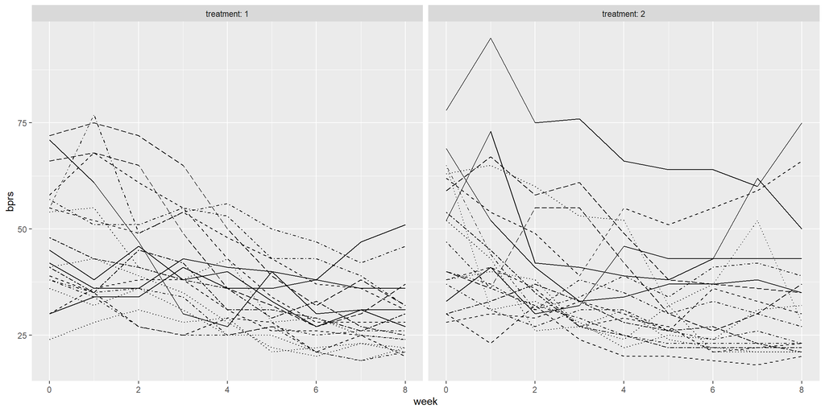

```r
ggplot(BPRSL, aes(x = week, y = bprs, linetype = subject)) +
  geom_line() +
  scale_linetype_manual(values = rep(1:10, times=4)) +
  facet_grid(. ~ treatment, labeller = label_both) +
  theme(legend.position = "none") +
  scale_y_continuous(limits = c(min(BPRSL$bprs), max(BPRSL$bprs)))
```

We standardize the data to see effects better

```r
BPRSL <- BPRSL %>%
  group_by(week) %>%
  mutate(stdbprs = (bprs - mean(bprs))/sd(bprs) ) %>%
  ungroup()
glimpse(BPRSL)
```

```
## Observations: 360
## Variables: 6
## $ treatment <fct> 1, 1, 1, 1, 1, 1, 1, 1, 1, 1, 1, 1, 1, 1, 1, 1, 1, 1...
## $ subject   <fct> 1, 2, 3, 4, 5, 6, 7, 8, 9, 10, 11, 12, 13, 14, 15, 1...
## $ weeks     <chr> "week0", "week0", "week0", "week0", "week0", "week0"...
## $ bprs      <int> 42, 58, 54, 55, 72, 48, 71, 30, 41, 57, 30, 55, 36, ...
## $ week      <int> 0, 0, 0, 0, 0, 0, 0, 0, 0, 0, 0, 0, 0, 0, 0, 0, 0, 0...
## $ stdbprs   <dbl> -0.4245908, 0.7076513, 0.4245908, 0.4953559, 1.69836...
```

Now we plot again with the standardised bprs

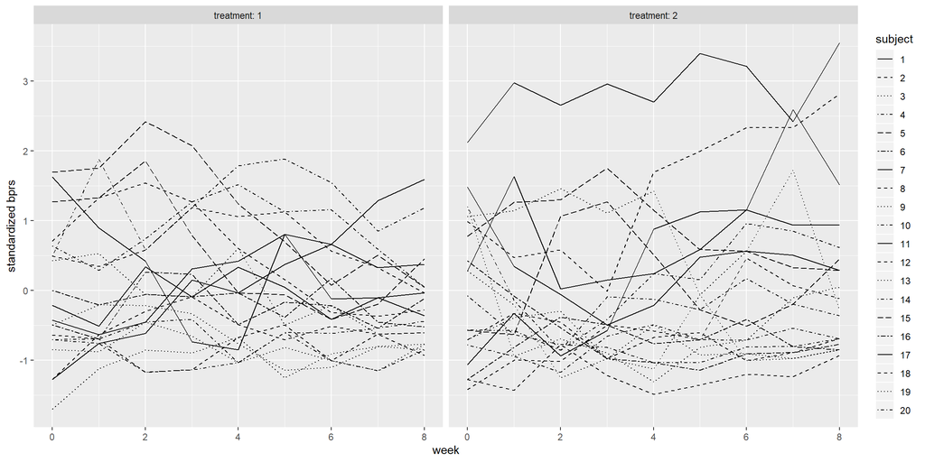

```r
ggplot(BPRSL, aes(x = week, y = stdbprs, linetype = subject)) +
  geom_line() +
  scale_linetype_manual(values = rep(1:10, times=4)) +
  facet_grid(. ~ treatment, labeller = label_both) +
  scale_y_continuous(name = "standardized bprs")
```

It is still hard to see clearly the overall effects, we use standard error of mean

```r
n <- BPRSL$week %>% unique() %>% length()

# Summary data with mean and standard error of bprs by treatment and week
BPRSS <- BPRSL %>%
  group_by(treatment, week) %>%
  summarise( mean = mean(bprs), se = sd(bprs)/sqrt(n) ) %>%
  ungroup()

# Glimpse the data
glimpse(BPRSS)
```

```
## Observations: 18
## Variables: 4
## $ treatment <fct> 1, 1, 1, 1, 1, 1, 1, 1, 1, 2, 2, 2, 2, 2, 2, 2, 2, 2
## $ week      <int> 0, 1, 2, 3, 4, 5, 6, 7, 8, 0, 1, 2, 3, 4, 5, 6, 7, 8
## $ mean      <dbl> 47.00, 46.80, 43.55, 40.90, 36.60, 32.70, 29.70, 29....
## $ se        <dbl> 4.534468, 5.173708, 4.003617, 3.744626, 3.259534, 2....
```

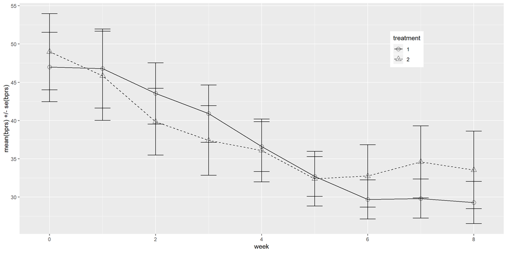

```r
# Plot the mean profiles
ggplot(BPRSS, aes(x = week, y = mean, linetype = treatment, shape = treatment)) +
  geom_line() +
  scale_linetype_manual(values = c(1,2)) +
  geom_point(size=3) +
  scale_shape_manual(values = c(1,2)) +
  geom_errorbar(aes(ymin=mean-se, ymax=mean+se, linetype="1"), width=0.3) +
  theme(legend.position = c(0.8,0.8)) +
  scale_y_continuous(name = "mean(bprs) +/- se(bprs)")
```

We can see that on average both treatments work. However treatment 1 seems to be working better from week 5 onwards. We have to analyse this statistically later.

Next we check if there is outliers in the data

```r
# Create a summary data by treatment and subject with mean as the summary variable (ignoring baseline week 0).
BPRSL8S <- BPRSL %>%
  filter(week > 0) %>%
  group_by(treatment, subject) %>%
  summarise( mean=mean(bprs) ) %>%
  ungroup()

# Glimpse the data
glimpse(BPRSL8S)
```

```
## Observations: 40
## Variables: 3
## $ treatment <fct> 1, 1, 1, 1, 1, 1, 1, 1, 1, 1, 1, 1, 1, 1, 1, 1, 1, 1...
## $ subject   <fct> 1, 2, 3, 4, 5, 6, 7, 8, 9, 10, 11, 12, 13, 14, 15, 1...
## $ mean      <dbl> 41.500, 43.125, 35.375, 52.625, 50.375, 34.000, 37.1...
```

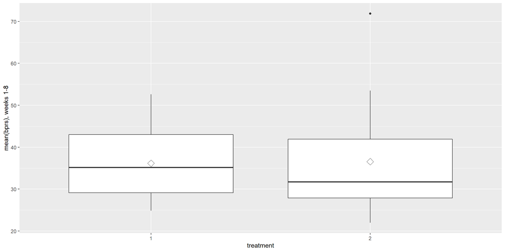

```r
# Draw a boxplot of the mean versus treatment
ggplot(BPRSL8S, aes(x = treatment, y = mean)) +
  geom_boxplot() +
  stat_summary(fun.y = "mean", geom = "point", shape=23, size=4, fill = "white") +
  scale_y_continuous(name = "mean(bprs), weeks 1-8")
```

```r
BPRSL8S1 <- filter(BPRSL8S, mean < 70)
```

Let’s add a baseline from original data to represent time zero before treatment

```r
BPRSL8S2 <- BPRSL8S %>% mutate(baseline = BPRS$week0)
```

And then make analysis if treatments have statistically different impact

```r
fit <- lm(mean ~ baseline + treatment, data = BPRSL8S2)
summary(fit)
```

```
##
## Call:
## lm(formula = mean ~ baseline + treatment, data = BPRSL8S2)
##
## Residuals:
##      Min       1Q   Median       3Q      Max
## -16.1729  -4.5994   0.1088   4.6703  21.0656
##
## Coefficients:
##             Estimate Std. Error t value Pr(>|t|)
## (Intercept) 13.07897    4.55710   2.870  0.00675 **
## baseline     0.49127    0.08943   5.493 3.05e-06 ***
## treatment2  -0.58879    2.49584  -0.236  0.81480
## ---
## Signif. codes:  0 '***' 0.001 '**' 0.01 '*' 0.05 '.' 0.1 ' ' 1
##
## Residual standard error: 7.872 on 37 degrees of freedom
## Multiple R-squared:  0.4494, Adjusted R-squared:  0.4196
## F-statistic:  15.1 on 2 and 37 DF,  p-value: 1.605e-05
```

```r
anova(fit)
```

```
## Analysis of Variance Table
##
## Response: mean
##           Df  Sum Sq Mean Sq F value    Pr(>F)
## baseline   1 1868.07 1868.07 30.1437 3.077e-06 ***
## treatment  1    3.45    3.45  0.0557    0.8148
## Residuals 37 2292.97   61.97
## ---
## Signif. codes:  0 '***' 0.001 '**' 0.01 '*' 0.05 '.' 0.1 ' ' 1
```

Treatments don’t have any statistical difference as treatment2 variable is not statistically significant.